# 2019-2020 Chicago Player Recuirment

### Small Forward

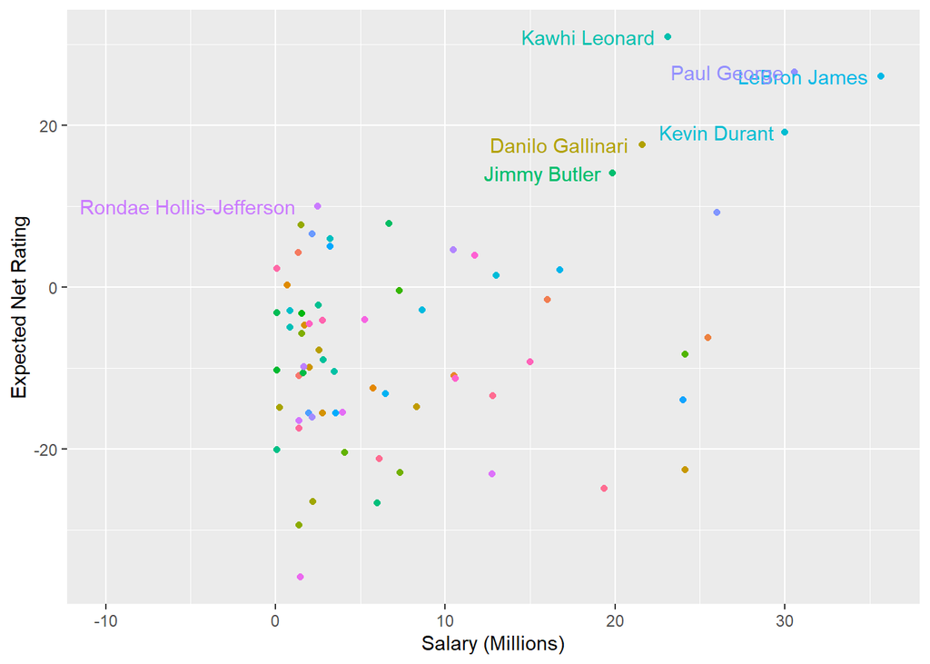

```r
players %>%
  filter(Pos == 'PF-SF' | Pos == 'SF' | Pos == 'SF-SG' | Pos == "SG-SF") %>%
  ggplot(aes(x = salary/1000000, y = exp_NRtg, color = player_name)) +
  geom_point() +
  geom_text(aes(label=ifelse(exp_NRtg > 10,as.character(player_name),'')),hjust=1.1,vjust=0.5) +
  theme(legend.position = "none")+
  expand_limits(x = -10)+
  xlab("Salary (Millions)") +
  ylab("Expected Net Rating")
```

Kawhi Leonard, Danilo Gallinari, and Jimmy Butler are superstars than should be considered, while Rondae Hollis-Jefferson should be a clear target for recuritment.

### Power Forward

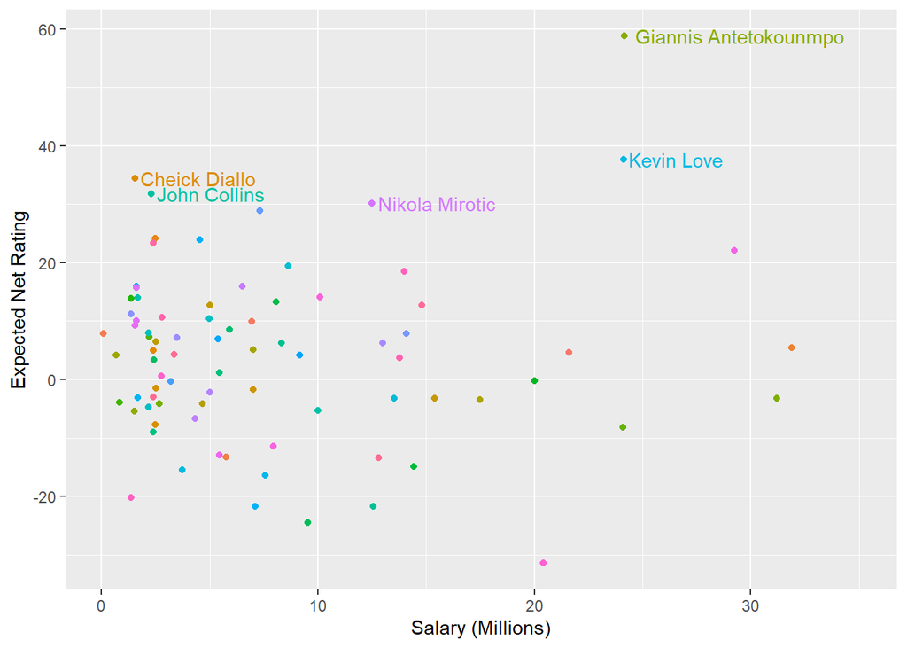

```r
players %>%
  filter(Pos == 'C-PF' | Pos == 'PF-C' | Pos == 'PF' | Pos == 'PF-SF' | Pos == "SG-PF") %>%
  ggplot(aes(x = salary/1000000, y = exp_NRtg, color = player_name)) +
  geom_point() +
  geom_text(aes(label=ifelse(exp_NRtg > 30,as.character(player_name),'')),hjust=-0.05,vjust=0.5) +
  expand_limits(x = 35)+
  theme(legend.position = "none")+
  xlab("Salary (Millions)") +
  ylab("Expected Net Rating")
```

Giannis Antetokounmpo was the MVP of the 2018-19 Season and would be an ideal target, even with a $24million price tag. John Collins, Christian Woods, and Cheick Diallo are also potential options.

### Center

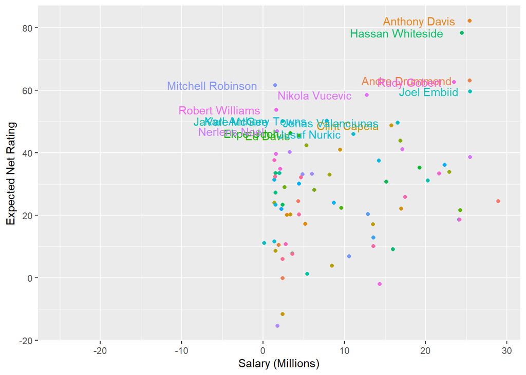

```r
players %>%
  filter(Pos == 'C-PF' | Pos == 'PF-C'| Pos == 'C') %>%
  ggplot(aes(x = salary/1000000, y = exp_NRtg, color = player_name)) +
  geom_point() +
  geom_text(aes(label=ifelse(exp_NRtg > 45,as.character(player_name),'')),hjust=1.2,vjust=0.5) +
  expand_limits(x = -25)+
  theme(legend.position = "none")+
  xlab("Salary (Millions)") +
  ylab("Expected Net Rating")
```

Karl-Anthony Towns is a strong center early in his career that would could potentially target. with Mitchell Robinson and Robert Williams as other potential target for the team.

# Chicago Bulls 2019-2020

Based on our analysis, let’s create a new data frame with our top 5 starting players for each position.

```r
starting_5 <- players %>%
  filter(player_name %in% c("Karl-Anthony Towns", "Giannis Antetokounmpo", "Kawhi Leonard", "Luka Doncic", "Michael Carter-Williams")) %>%
  arrange(desc(salary))

sum(starting_5$salary)
```

```
## [1] 63147927
```

The sum of the Chicago Bulls starting team for 2019-2020 based on my analysis would be $63,147,927 Million, which leaves $54,852,073 Million for the remaining team.

Alternative Player that can be recruited are:

PG: Ben Simmons and Kemba Walker

SG: Jeremy Lamb, Pat Connaughton, and Buddy Hield

SF: Danilo Gallinari, Jimmy Butler, Rondae Hollis-Jefferson

PF: John Collins, Christian Woods, and Cheick Diallo

C: Mitchell Robinson and Robert Williams